# Chapter 2 Notes

Loren Serfass

12/25/2014

```r
library('ISLR')
library('MASS')
library('ggplot2')
library('plyr')
```

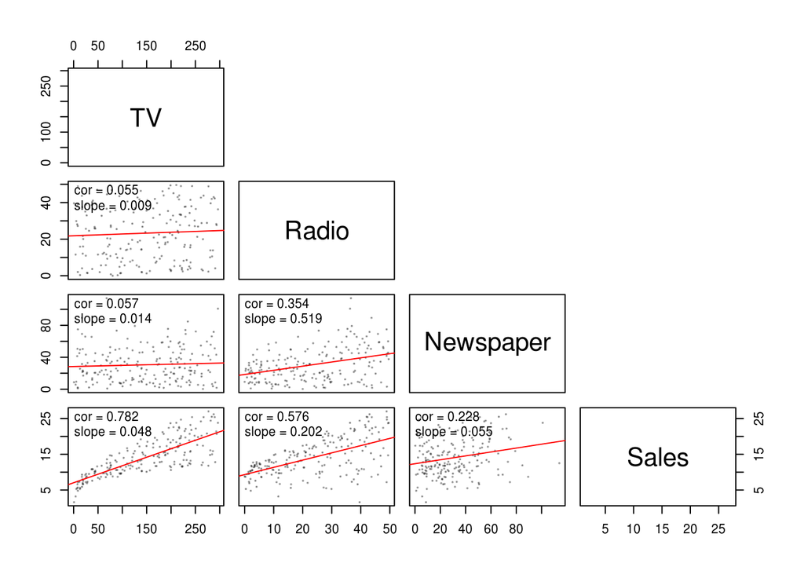

```r
ads <- read.csv('Advertising.csv')
ads <- ads[,-1] # what's up with that annoying first column

myfun <- function(x, y) {
    points(x, y, pch=20, cex=.3, col=rgb(0,0,0,.3)) # transparent points!
    m <- lm(y ~ x)
    abline(m$coefficients[1], m$coefficients[2], col='red')
    # abline(reg=lm(y ~ x), col='red') # would also work
    text(min(x), y=max(y), adj=c(0,1),
         paste('cor = ', round(cor(x,y), digits=3), '\n',
               'slope = ', round(m$coefficients[2],digits=3), sep=''))
}
pairs(ads, lower.panel=myfun, upper.panel={}) # pch=1, cex=.7, panel=myfun)
```

## My playing around

Plotting test-set average squared deviation against a smoothing parameter

Here’s my invented function we’ll be trying to fit:

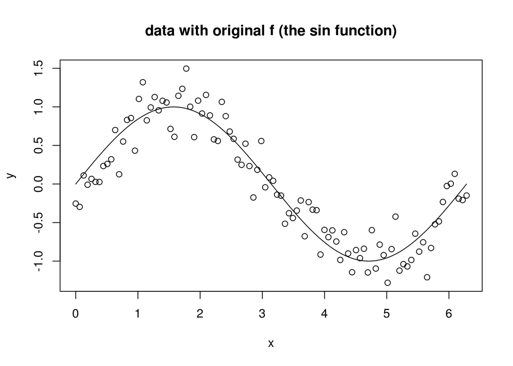

```r
f <- function(x) { sin(x) }
n <- 100
eps.sd <- .3
x <- seq(from=0, to=2*pi, length.out = n)
y <- f(x) + rnorm(n,sd=eps.sd)
plot(x,y, main="data with original f (the sin function)")
curve(sin, from=0, to=2*pi, add=T)
```

Fitting the function with spline, with varying smoothing parameters. Notice how sp = 0.8 gets the closest to the original sine curve.

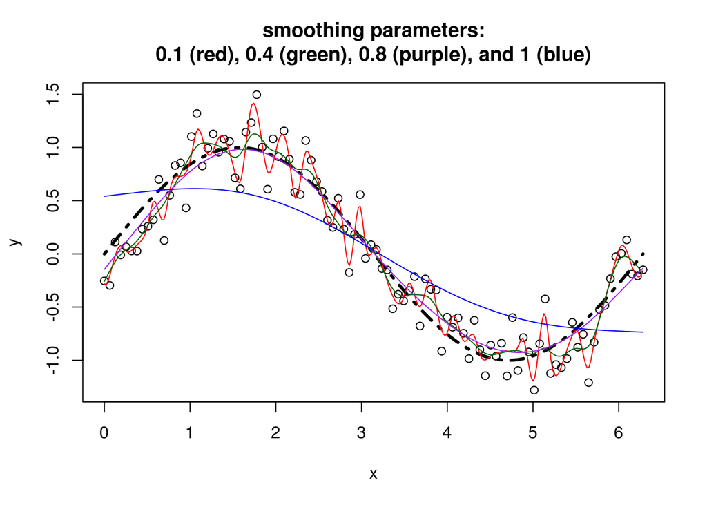

```r
plot(x,y, main="smoothing parameters:\n0.1 (red), 0.4 (green), 0.8 (purple), and 1 (blue)")
curve(sin, 0, 2*pi, add=T, lty=4, lwd=3)
lines(predict(smooth.spline(x,y, sp=.1),seq(0,2*pi,length=300)), col='red')
lines(predict(smooth.spline(x,y, sp=.4),seq(0,2*pi,length=300)), col='darkgreen')
lines(predict(smooth.spline(x,y, sp=.8),seq(0,2*pi,length=300)), col='purple')
lines(predict(smooth.spline(x,y, sp=1),seq(0,2*pi,length=300)), col='blue')
```

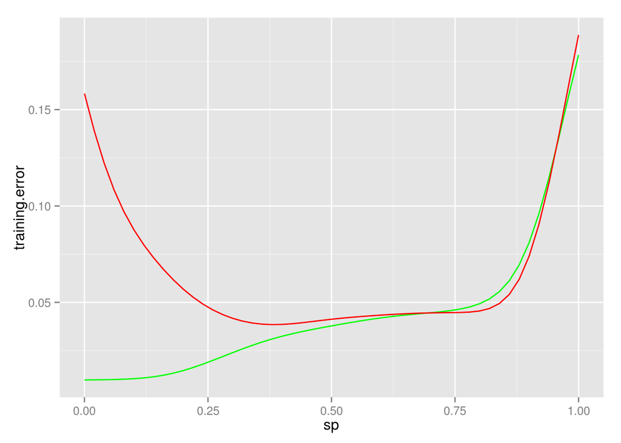

```r
training.size <- 90
samp <- sample(n, size=training.size)

try.smoothing.parameter <- function(sp) {
    ss <- smooth.spline(x[samp],y[samp],spar = sp)
    training.error <- sum((ss$yin - ss$y)^2)/training.size
    test.predictions <- predict(ss, x[-samp])
    test.error <- sum((test.predictions$y - y[-samp])^2)/(n-training.size)
    data.frame(sp, training.error, test.error)
}
pars <- seq(from=0,to=1,by=.02)
learning.curves <- adply(.data=pars, .margins=1, .fun=try.smoothing.parameter)
ggplot(learning.curves, aes(x=sp)) + geom_line(aes(y=training.error),color='green') +
    geom_line(aes(y=test.error),color='red')
```

## k-fold cross-validation to find best smoothing parameter of a smoothing spline

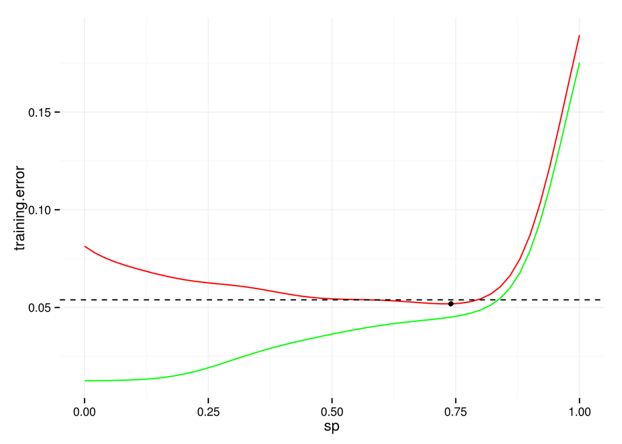

```r
# TODO: for use in k-fold cross-validation function
get.group.sizes <- function(n, k) {
    ceil <- ceiling(n/k)
    num.to.deduct <- ceil*k - n
    sizes <- rep(ceil, times=k)
    if (num.to.deduct > 0) sizes[1:num.to.deduct] <- ceil - 1
    sizes
}

# k-fold cross validation
# TODO: make this a function of k and everthing else (pars, function, data, model, etc.)
k <- 10 # do not use this method for large k.
pars <- seq(from=0,to=1,by=.02)

samp <- sample(n) # randomly order an index to the data points
sz <- get.group.sizes(n, k)
k.fold.cv.spline <- function(sp) {
    start <- 1
    training.error <- 0
    test.error <- 0
    for (i in 1:k) {
        test.set <- start:(start + sz[i] - 1)
        ss <- smooth.spline(x[samp[-test.set]], y[samp[-test.set]], spar=sp)
        training.error <- training.error + sum((ss$yin - ss$y)^2)
        test.predictions <- predict(ss, x[samp[test.set]])
        test.error <- test.error + sum((test.predictions$y - y[samp[test.set]])^2)
        start <- start + sz[i]
    }
    training.error <- training.error / (n * (k-1))
    test.error <- test.error / n
    data.frame(sp, training.error, test.error)
}
error.rates <- adply(.data=pars, .margins=1, .fun=k.fold.cv.spline)
best.sp.index <- which.min( error.rates$test.error)
ggplot(error.rates, aes(x=sp)) + geom_line(aes(y=training.error),color='green') +
    geom_line(aes(y=test.error),color='red') + theme_minimal() +
    geom_hline(yintercept=sum((y - f(x))^2)/n, linetype='dashed') +
    geom_point(x=pars[best.sp.index], y=error.rates$test.error[best.sp.index])
```

```r
pars[ which.min( learning.curves$test.error)]
```

```
## [1] 0.38
```

## Back to chapter 2 notes…

Plotting Income vs Education, with a loess smoother (not the f the data were simulated from):

```
## geom_smooth: method="auto" and size of largest group is <1000, so using loess. Use 'method = x' to change the smoothing method.
```

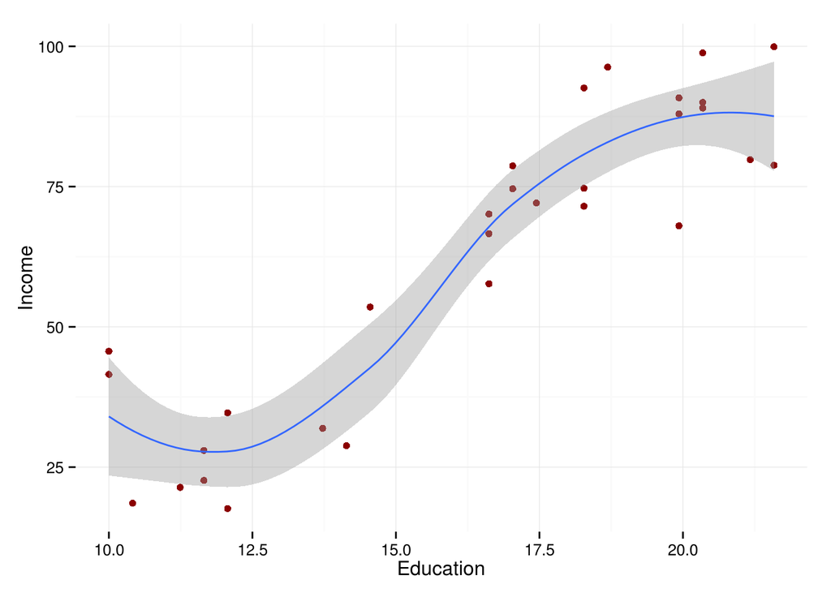

```r
income <- read.csv('Income2.csv')
income <- income[,-1]
ggplot(income, aes(Education, Income)) + geom_point(color='darkred') + geom_smooth(span=.9) + theme_minimal()
```

### Prediction

Getting an f-hat estimate of f.

### Inference

Estimating f, but also answering such questions as: Which predictors are assoc w/ the response? What is the relationship between the response and each of the predictors? Can the relationship be summarized as a linear equation, or is the relationship more complicated?

Some models are more appropriate for prediction than inference, and vice versa.

## Parametric methods of model-building

2 steps:

1: make assumption (e.g., linearity)

2: fit the training data, choosing parameters that [minimize a cost function?]

More *flexible* models estimate a greater number of parameters, and can result in *overfitting*.

## Non-Parametric methods

E.g. thin-plate spline. Non-parametric methods make no “explicit” assumptions. “Seek an estimate neither too rough nor wiggly.” *They require a large number of observations.*

## Flexibility vs interpretability

Interpretable models are more useful for inference.

Continuum from high interpret / low flexibility to the opposite:

lasso, subset selection

least squares

generalized additive models, trees

bagging, boosting,

support vector machines

## Supervised vs unsupervised

Clustering (un-supervised)

## Regression vs classification

Classification: when the output variable in a bunch of classes.

# Assessing model accuracy

## Measuring the quality of fit

MSE (mean squared error), minimized on the test set. **Others?**

## The bias-variance trade-off

$E((y_{0} - \hat{f}(x_{0}))^2) = Var(\hat{f}(x_{0})) + [Bias(\hat{f}(x_{0}))]^2 + Var(\epsilon)$

The left-hand side (and the right) is the *expected test MSE*.

*Variance*: the amount by which $\hat{f}$ would change if we estimated it under different training sets. Ideally $\hat{f}$ would not vary much when estimated using different training sets. If it does, the learning method has *high variance*. More flexible methods have higher variance.

*Bias*: the error introduced by reducing a “complicated real-life situation” to a simple model.

When f is unknown, it is impossible to calculate the expected test MSE, bias, and variance (?). Cross-validation allows you to estimate the test MSE.